# STAT340 Lecture 10: Linear Regression and Variable Selection

Apr 11

**Readings:** ISLR Sections 6.1 and 6.2

In our previous lecture, we discussed how to use cross-validation to choose among models. We concentrated on choosing among a family of linear regression models that varied in their orders, in the sense that they included as predictors all powers of the horsepower variable `hp` up to some maximum power to predict gas mileage. Hopefully it is clear how we could modify our approach to, say, choose which variables we do and don’t include in a model (e.g., as in the Pima diabetes data set we saw in discussion section).

Ultimately, our goal was to choose, from among a set of predictors that we *could* include in our model (e.g., powers of `hp`, in the case of the `mtcars` example we saw in the last lecture), which predictors to actually include in the model. This task is often called *variable selection*.

In this lecture, we’ll see a few different approaches to variable selection that do not rely on cross-validation. These alternative methods have the advantage of not trying to estimate the unknown model error on unseen data. On the other hand, these methods can be more computationally intensive and tend to come with fewer theoretical guarantees.

This is not to suggest, however, that the methods in this lecture are at odds with cross-validation. In actual research papers and in industry applications, you’ll often see both CV and some of the methods presented below used in tandem to select the best model for the job.

## Learning objectives

After this lecture, you will be able to

- Explain the problem of variable selection and model selection more generally.
- Explain subset selection methods, including forward and backward stepwise selection.
- Explain and apply adjustment methods including Mallow’s $C_p$, Akaike Information Criterion, Bayesian Information Criterion and adjusted $R^2$.
- Explain and apply regularization and shrinkage methods, including ridge regression and the LASSO.

## Setup: linear regression and fitting

We will focus in this lecture on linear regression, bearing in mind that the ideas introduced here apply equally well to other regression and prediction methods (e.g., logistic regression). Let’s recall that multiple linear regression models a response $Y \in \mathbb{R}$ as a linear (again, technically affine– linear plus an intercept!) function of a set of $p$ predictors plus normal noise:
$$Y = \beta_0 + \beta_1 X_1 + \beta_2 X_2 + \cdots + \beta_p X_p + \epsilon.$$
Here, $\epsilon$ is mean-zero normal with unknown variance $\sigma^2 > 0$, and the variables $X_1,X_2,\dots,X_p$ are the *predictors*. We often refer to $p$, the number of predictors, as the *dimension* of the problem, because the data (well, the vector of predictors, anyway), lies in $p$-dimensional space. Collecting the coefficients into a vector $(\beta_0,\beta_1,\dots,\beta_p) \in \mathbb{R}^{p+1}$ and creating a vector $X=(1,X_1,X_2,\dots,X_p) \in \mathbb{R}^p$, we can write this more succinctly as (if you have not taken linear regression, you can safely ignore this, we’re just including it because it’s a common notation)
$$Y = \beta^T X + \epsilon.$$
In multiple linear regression, we observe a collection of predictor-response pairs $(X_i,Y_i)$ for $i=1,2,\dots,n$, with
$$X_i = (1,X_{i,1},X_{i,2},\dots,X_{i,p}) \in \mathbb{R}^{p+1}.$$
Note that here we are including the intercept term $1$ in the vector of predictors for ease of notation. This is a common notational choice, so we’re including it here to get you used to seeing this. Of course, this is not universal– it’s one of those conventions that you have to be careful of and check what you are reading.

### Overview: variable selection

So we have $p$ variables (plus an intercept term), and we want to select which ones to include in our model. There are many reasons to want to do this, but let’s just highlight three of them:

- If there are many “useless” variables (i.e., ones that are not good predictors of the response), then including them in the model can make our predictions less accurate. Thus, we would like to proactively identify which variables are not useful, and avoid including them in the model in the first place.
- A model with fewer variables is simpler, and we like simple models! Explaining, say, heart attack risk as a function of two or three factors is a lot easier to use than a model that uses ten or twenty factors.
- If the number of predictors $p$ is too large (say, larger than $n$– a common occurrence in genomic studies, for example), our estimates of the coefficients are very unstable. Variable selection and related tools give us a way to introduce stability in the form of *regularization*, which we will talk about below.

## Best subset selection

So, we have $p$ predictor variables available to us, and we want to choose which of them to actually include in our model.

Well, the most obvious solution is to just try all possible combinations of features, train a model using each combination, and keep the best one (measured by, say, residual sum of squares).

This would have an obvious drawback: we have already seen that we can trivially improve the RSS of our model by adding variables. So the models that include more variables would do better, even if those variables did not actually lead to better model error on unseen data.

The solution to this is to do the following:

1. For each $k=1,2,\dots,p$, for every set of $k$ different variables, fit a model and keep the model that best fits the data (measured by RSS). Call this model $M_k$.
2. Use CV (or some other tool like AIC or adjusted $R^2$, which we’ll discuss below) to select among the models $M_1,M_2,\dots,M_p$.

This is called *best subset selection*. It is implemented in R in, for example, the `leaps` library the function `regsubsets`, which gets called in more or less the same way as `lm`. See (here)[https://cran.r-project.org/web/packages/leaps/index.html] for documentation if you’re interested.

There is one rather glaring problem with best subset selection, though:

**Question:** if there are $p$ predictors, how many models does best subset selection fit before it makes a decision?

So once $p$ is even moderately large, best subset selection is computationally expensive, and we need to do something a little more clever.

## Stepwise selection

So best subset selection is expensive because we have to try every possible model, and then choose among the best “size-$k$” model for each $k=1,2,\dots,p$. How might we cut down on the computational expense?

Stepwise selection methods avoid exhaustively checking all $2^p$ possible models by starting with a particular model and adding or removing one variable at a time (i.e., in “steps”).

The important part is in how we decide which predictor to add or remove from the model at a particular time.

### Forward stepwise selection

The most obvious (to me, anyway) way to avoid checking every possible model is to start with a “null” model (i.e., no predictors, just an intercept term), then repeatedly add the “best” predictor not already in the model. That is,

1. Start by fitting the “null” model, with just an intercept term. Call it $M_0$.
2. For each $k=1,2,\dots,p$, among the $p-k$ predictors not already in the model, add the one that yields the biggest improvement in RSS. Call this model, which includes $k$ predictors and the intercept term, $M_k$.
3. Use CV or some other method (e.g., an information criterion, which we will discuss soon) to choose among $M_0,M_1,M_2,\dots,M_p$.

The important thing is that in Step 2 above, for each $k=1,2,\dots,p$, we need to fit $p-k$ different models. Thus, in total (i.e., summing over $k=0,1,2,\dots,p$), we end up fitting
$$1+ \sum_{k=0}^{p-1} (p-k)
= 1+p^2 - \frac{(p-1)p}{2} = 1+\frac{ 2p^2 - p^2 + p }{2}
= 1+ \frac{ p(p+1)}{2}$$
different models. To get a sense of what a big improvement this is, when $p$ is large, this right-hand side is approximately $p^2/2$. Compare that with $2^p$, which is a MUCH larger number. For example, when $p=10$, $2^{10} \approx 1000$, while $10^2/2 \approx 50$. When $p=20$, $2^{20} \approx 1,000,000$ while $20^2/2 \approx 200$.

Of course, the drawback is that forward stepwise selection might “miss” the optimal model, since it does not exhaustively fit every possible model the way that best subset selection does.

### Example

```r
library(MASS)

lm1 = lm(mpg ~ 1, data=mtcars)
lm2 = lm(mpg ~ ., data=mtcars)

lm.forward = stepAIC(lm1, direction="forward", scope=list(upper=lm2,lower=lm1))
```

```
## Start:  AIC=115.94
## mpg ~ 1
##
##        Df Sum of Sq     RSS     AIC
## + wt    1    847.73  278.32  73.217
## + cyl   1    817.71  308.33  76.494
## + disp  1    808.89  317.16  77.397
## + hp    1    678.37  447.67  88.427
## + drat  1    522.48  603.57  97.988
## + vs    1    496.53  629.52  99.335
## + am    1    405.15  720.90 103.672
## + carb  1    341.78  784.27 106.369
## + gear  1    259.75  866.30 109.552
## + qsec  1    197.39  928.66 111.776
## <none>              1126.05 115.943
##
## Step:  AIC=73.22
## mpg ~ wt
##
##        Df Sum of Sq    RSS    AIC
## + cyl   1    87.150 191.17 63.198
## + hp    1    83.274 195.05 63.840
## + qsec  1    82.858 195.46 63.908
## + vs    1    54.228 224.09 68.283
## + carb  1    44.602 233.72 69.628
## + disp  1    31.639 246.68 71.356
## <none>              278.32 73.217
## + drat  1     9.081 269.24 74.156
## + gear  1     1.137 277.19 75.086
## + am    1     0.002 278.32 75.217
##
## Step:  AIC=63.2
## mpg ~ wt + cyl
##
##        Df Sum of Sq    RSS    AIC
## + hp    1   14.5514 176.62 62.665
## + carb  1   13.7724 177.40 62.805
## <none>              191.17 63.198
## + qsec  1   10.5674 180.60 63.378
## + gear  1    3.0281 188.14 64.687
## + disp  1    2.6796 188.49 64.746
## + vs    1    0.7059 190.47 65.080
## + am    1    0.1249 191.05 65.177
## + drat  1    0.0010 191.17 65.198
##
## Step:  AIC=62.66
## mpg ~ wt + cyl + hp
##
##        Df Sum of Sq    RSS    AIC
## <none>              176.62 62.665
## + am    1    6.6228 170.00 63.442
## + disp  1    6.1762 170.44 63.526
## + carb  1    2.5187 174.10 64.205
## + drat  1    2.2453 174.38 64.255
## + qsec  1    1.4010 175.22 64.410
## + gear  1    0.8558 175.76 64.509
## + vs    1    0.0599 176.56 64.654
```

```r
summary(lm.forward)
```

```
##
## Call:
## lm(formula = mpg ~ wt + cyl + hp, data = mtcars)
##
## Residuals:
##     Min      1Q  Median      3Q     Max
## -3.9290 -1.5598 -0.5311  1.1850  5.8986
##
## Coefficients:
##             Estimate Std. Error t value Pr(>|t|)
## (Intercept) 38.75179    1.78686  21.687  < 2e-16 ***
## wt          -3.16697    0.74058  -4.276 0.000199 ***
## cyl         -0.94162    0.55092  -1.709 0.098480 .
## hp          -0.01804    0.01188  -1.519 0.140015
## ---
## Signif. codes:  0 '***' 0.001 '**' 0.01 '*' 0.05 '.' 0.1 ' ' 1
##
## Residual standard error: 2.512 on 28 degrees of freedom
## Multiple R-squared:  0.8431, Adjusted R-squared:  0.8263
## F-statistic: 50.17 on 3 and 28 DF,  p-value: 2.184e-11
```

We can quickly check the residuals of this model.

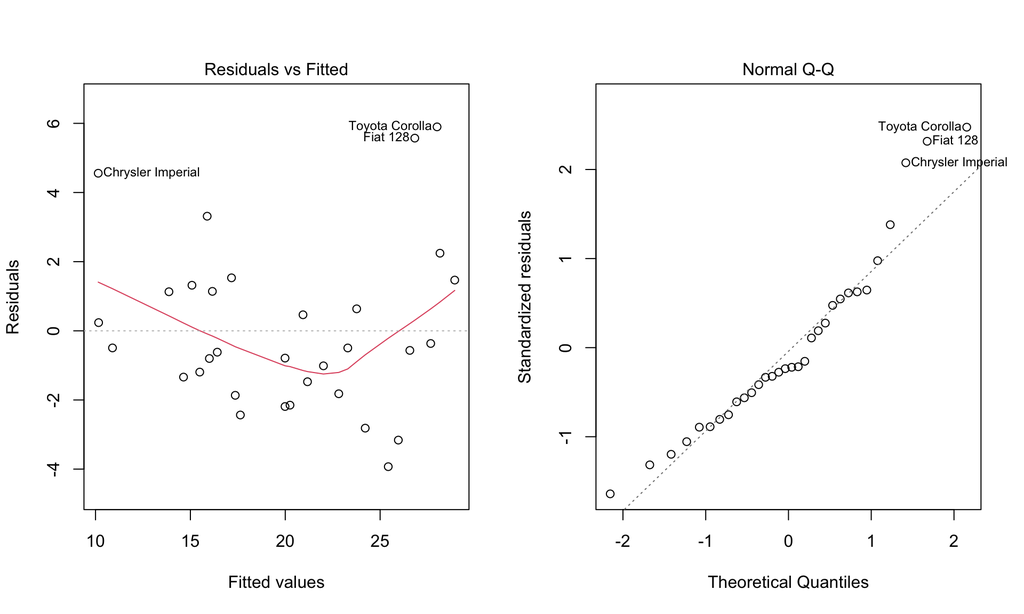

```r
par(mfrow=c(1,2))
plot(lm.forward,which=1:2)
```

### Backward stepwise selection

Well, if we can do forward stepwise selection, why not go backwards?

In *backward stepwise selection*, we start with the full model (i.e., a model with all $p$ predictors), and iteratively remove one predictor at a time, always removing the predictor that decreases RSS the least.

Just like forward stepwise regression, this decreases the number of models we have to fit from $2^p$ to something more like (approximately) $p^2/2$.

```r
lm.backward = stepAIC(lm2, direction="backward", scope=list(upper=lm2,lower=lm1))
```

```
## Start:  AIC=70.9
## mpg ~ cyl + disp + hp + drat + wt + qsec + vs + am + gear + carb
##
##        Df Sum of Sq    RSS    AIC
## - cyl   1    0.0799 147.57 68.915
## - vs    1    0.1601 147.66 68.932
## - carb  1    0.4067 147.90 68.986
## - gear  1    1.3531 148.85 69.190
## - drat  1    1.6270 149.12 69.249
## - disp  1    3.9167 151.41 69.736
## - hp    1    6.8399 154.33 70.348
## - qsec  1    8.8641 156.36 70.765
## <none>              147.49 70.898
## - am    1   10.5467 158.04 71.108
## - wt    1   27.0144 174.51 74.280
##
## Step:  AIC=68.92
## mpg ~ disp + hp + drat + wt + qsec + vs + am + gear + carb
##
##        Df Sum of Sq    RSS    AIC
## - vs    1    0.2685 147.84 66.973
## - carb  1    0.5201 148.09 67.028
## - gear  1    1.8211 149.40 67.308
## - drat  1    1.9826 149.56 67.342
## - disp  1    3.9009 151.47 67.750
## - hp    1    7.3632 154.94 68.473
## <none>              147.57 68.915
## - qsec  1   10.0933 157.67 69.032
## - am    1   11.8359 159.41 69.384
## - wt    1   27.0280 174.60 72.297
##
## Step:  AIC=66.97
## mpg ~ disp + hp + drat + wt + qsec + am + gear + carb
##
##        Df Sum of Sq    RSS    AIC
## - carb  1    0.6855 148.53 65.121
## - gear  1    2.1437 149.99 65.434
## - drat  1    2.2139 150.06 65.449
## - disp  1    3.6467 151.49 65.753
## - hp    1    7.1060 154.95 66.475
```

[output cut: 44 more lines]

```
##        Df Sum of Sq    RSS    AIC
## - hp    1     9.219 169.29 61.307
## <none>              160.07 61.515
## - qsec  1    20.225 180.29 63.323
## - am    1    25.993 186.06 64.331
## - wt    1    78.494 238.56 72.284
##
## Step:  AIC=61.31
## mpg ~ wt + qsec + am
##
##        Df Sum of Sq    RSS    AIC
## <none>              169.29 61.307
## - am    1    26.178 195.46 63.908
## - qsec  1   109.034 278.32 75.217
## - wt    1   183.347 352.63 82.790
```

```r
summary(lm.backward)
```

```
##
## Call:
## lm(formula = mpg ~ wt + qsec + am, data = mtcars)
##
## Residuals:
##     Min      1Q  Median      3Q     Max
## -3.4811 -1.5555 -0.7257  1.4110  4.6610
##
## Coefficients:
##             Estimate Std. Error t value Pr(>|t|)
## (Intercept)   9.6178     6.9596   1.382 0.177915
## wt           -3.9165     0.7112  -5.507 6.95e-06 ***
## qsec          1.2259     0.2887   4.247 0.000216 ***
## am            2.9358     1.4109   2.081 0.046716 *
## ---
## Signif. codes:  0 '***' 0.001 '**' 0.01 '*' 0.05 '.' 0.1 ' ' 1
##
## Residual standard error: 2.459 on 28 degrees of freedom
## Multiple R-squared:  0.8497, Adjusted R-squared:  0.8336
## F-statistic: 52.75 on 3 and 28 DF,  p-value: 1.21e-11
```

We can also check these residuals

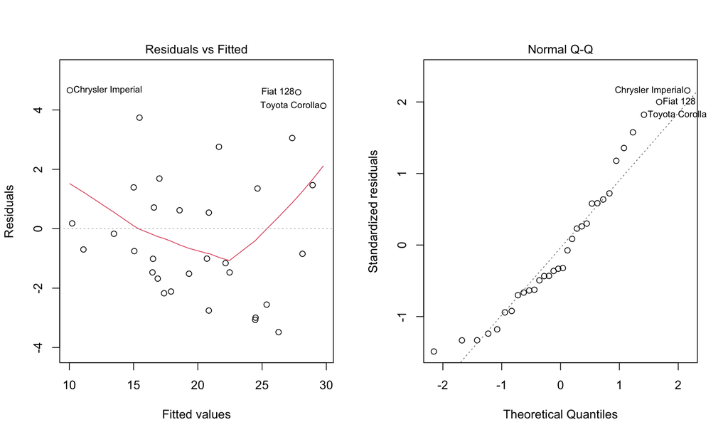

```r
par(mfrow=c(1,2))
plot(lm.backward,which=1:2)
```

### Hybrid approaches: the best of both worlds?

It is outside the scope of this course, but there do exist stepwise selection methods that try to combine forward and backward stepwise selection. For example, we can alternately add and remove variables as needed. This can be helpful when, for example, a predictor is useful “early” in the selection process, but becomes a less useful predictor once other predictors have been included.

Suppose you want to use bidirectional selection. Suppose you also want to consider a more complex model, where you allow for all possible 2-way interactions as well as a few higher order terms (looking at a pairs plot, might be a good idea to consider squares of `disp`, `hp`, and maybe even`drat` and `wt`). You can specify these by just modifying the scope.

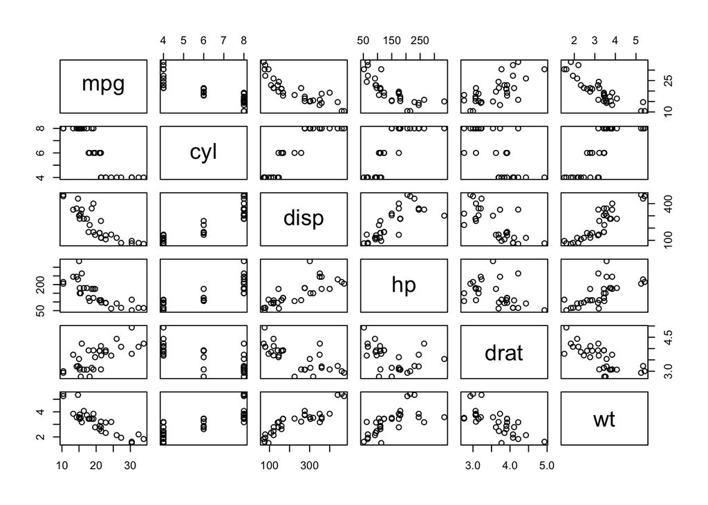

```r
pairs(mtcars[1:6])
```

```r
lm1 = lm(mpg ~ 1, data=mtcars)
lm2 = lm(mpg ~ (.)^2+I(disp^2)+I(hp^2)+I(drat^2)+I(wt^2), data=mtcars)

lm.both = stepAIC(lm1, direction="both", scope=list(upper=lm2,lower=lm1))
```

```
## Start:  AIC=115.94
## mpg ~ 1
##
##             Df Sum of Sq     RSS     AIC
## + wt         1    847.73  278.32  73.217
## + cyl        1    817.71  308.33  76.494
## + disp       1    808.89  317.16  77.397
## + I(wt^2)    1    723.28  402.76  85.044
## + hp         1    678.37  447.67  88.427
## + I(disp^2)  1    675.72  450.32  88.615
## + I(drat^2)  1    525.80  600.25  97.811
## + drat       1    522.48  603.57  97.988
## + I(hp^2)    1    497.32  628.73  99.295
## + vs         1    496.53  629.52  99.335
## + am         1    405.15  720.90 103.672
## + carb       1    341.78  784.27 106.369
## + gear       1    259.75  866.30 109.552
## + qsec       1    197.39  928.66 111.776
## <none>                   1126.05 115.943
##
## Step:  AIC=73.22
## mpg ~ wt
##
##             Df Sum of Sq     RSS     AIC
## + cyl        1     87.15  191.17  63.198
## + hp         1     83.27  195.05  63.840
## + qsec       1     82.86  195.46  63.908
## + I(wt^2)    1     74.58  203.75  65.236
## + I(hp^2)    1     55.22  223.11  68.141
## + vs         1     54.23  224.09  68.283
## + carb       1     44.60  233.72  69.628
## + disp       1     31.64  246.68  71.356
## <none>                    278.32  73.217
## + I(drat^2)  1     10.17  268.16  74.027
## + drat       1      9.08  269.24  74.156
## + I(disp^2)  1      1.64  276.68  75.028
## + gear       1      1.14  277.19  75.086
## + am         1      0.00  278.32  75.217
## - wt         1    847.73 1126.05 115.943
##
```

[output cut: 45 more lines]

```
## + gear       1     7.005 126.67 56.028
## + am         1     4.461 129.22 56.665
## + hp         1     4.427 129.25 56.673
## + drat       1     2.020 131.66 57.264
## + wt:qsec    1     1.984 131.70 57.272
## + I(drat^2)  1     1.608 132.07 57.364
## + I(wt^2)    1     1.561 132.12 57.375
## + I(hp^2)    1     0.941 132.74 57.525
## + vs         1     0.319 133.36 57.674
## + disp       1     0.237 133.44 57.694
## + carb       1     0.081 133.60 57.731
## + I(disp^2)  1     0.026 133.65 57.745
## + cyl:qsec   1     0.003 133.68 57.750
## - qsec       1    23.296 156.98 58.891
## - wt:cyl     1    46.925 180.60 63.378
```

```r
summary(lm.both)
```

```
##
## Call:
## lm(formula = mpg ~ wt + cyl + qsec + wt:cyl, data = mtcars)
##
## Residuals:
##     Min      1Q  Median      3Q     Max
## -4.6822 -1.3668 -0.0789  1.0943  4.7947
##
## Coefficients:
##             Estimate Std. Error t value Pr(>|t|)
## (Intercept)  41.6429     8.2002   5.078 2.47e-05 ***
## wt          -10.8195     2.3977  -4.512 0.000113 ***
## cyl          -3.3927     0.9633  -3.522 0.001543 **
## qsec          0.7572     0.3491   2.169 0.039044 *
## wt:cyl        0.9766     0.3172   3.079 0.004735 **
## ---
## Signif. codes:  0 '***' 0.001 '**' 0.01 '*' 0.05 '.' 0.1 ' ' 1
##
## Residual standard error: 2.225 on 27 degrees of freedom
## Multiple R-squared:  0.8813, Adjusted R-squared:  0.8637
## F-statistic: 50.11 on 4 and 27 DF,  p-value: 4.134e-12
```

Hmm looks like it got stuck and didn’t keep going, probably because the constant model isn’t a very good starting point. Let’s try again but with different starting conditions, see if we can get a better fit.

```r
lm1 = lm(mpg ~ hp+wt+disp+cyl+qsec+I(hp^2), data=mtcars)
lm2 = lm(mpg ~ (.)^2+I(disp^2)+I(hp^2)+I(drat^2)+I(wt^2), data=mtcars)

lm.both2 = stepAIC(lm1, direction="both", scope=list(upper=lm2,lower=lm1))
```

```
## Start:  AIC=63.6
## mpg ~ hp + wt + disp + cyl + qsec + I(hp^2)
##
##             Df Sum of Sq    RSS    AIC
## + cyl:wt     1    34.468 116.29 57.292
## + I(disp^2)  1    33.618 117.14 57.525
## + I(wt^2)    1    32.945 117.82 57.708
## + hp:wt      1    32.012 118.75 57.961
## + disp:wt    1    31.321 119.44 58.147
## + cyl:disp   1    30.162 120.60 58.455
## + disp:hp    1    22.113 128.65 60.523
## + cyl:hp     1    15.853 134.91 62.043
## + am         1     9.656 141.10 63.480
## <none>                   150.76 63.599
## + wt:qsec    1     8.412 142.35 63.761
## + hp:qsec    1     5.346 145.41 64.443
## + gear       1     4.882 145.88 64.545
## + cyl:qsec   1     2.642 148.12 65.033
## + drat       1     1.368 149.39 65.307
## + I(drat^2)  1     1.038 149.72 65.378
## + vs         1     0.698 150.06 65.450
## + carb       1     0.134 150.63 65.570
## + disp:qsec  1     0.029 150.73 65.593
##
## Step:  AIC=57.29
## mpg ~ hp + wt + disp + cyl + qsec + I(hp^2) + wt:cyl
##
##             Df Sum of Sq    RSS    AIC
## + gear       1    12.156 104.14 55.759
## <none>                   116.29 57.292
## + hp:qsec    1     6.221 110.07 57.533
## + I(disp^2)  1     3.403 112.89 58.342
## + am         1     2.364 113.93 58.635
## + disp:qsec  1     1.800 114.49 58.793
## + cyl:disp   1     1.611 114.68 58.845
## + cyl:hp     1     1.286 115.01 58.936
## + disp:hp    1     1.129 115.16 58.980
## + cyl:qsec   1     0.993 115.30 59.017
## + wt:qsec    1     0.775 115.52 59.078
## + drat       1     0.628 115.67 59.119
```

[output cut: 138 more lines]

```
## + am         1     0.513 47.491 40.634
## + hp:wt      1     0.318 47.686 40.765
## + disp:wt    1     0.287 47.717 40.785
## + cyl:qsec   1     0.284 47.720 40.788
## + disp:hp    1     0.107 47.897 40.906
## + hp:gear    1     0.043 47.961 40.949
## + disp:qsec  1     0.022 47.982 40.963
## + disp:gear  1     0.017 47.987 40.966
## + I(wt^2)    1     0.007 47.997 40.973
## + drat       1     0.007 47.997 40.973
## + I(drat^2)  1     0.003 48.001 40.976
## - hp:qsec    1     9.296 57.300 42.642
## - wt:cyl     1    20.436 68.440 48.327
## - wt:gear    1    40.962 88.966 56.720
## - wt:qsec    1    42.772 90.776 57.365
```

```r
summary(lm.both2)
```

```
##
## Call:
## lm(formula = mpg ~ hp + wt + disp + cyl + qsec + I(hp^2) + gear +
##     wt:cyl + wt:qsec + wt:gear + hp:qsec + qsec:gear, data = mtcars)
##
## Residuals:
##      Min       1Q   Median       3Q      Max
## -2.34925 -0.84218 -0.01516  0.79279  2.61134
##
## Coefficients:
##               Estimate Std. Error t value Pr(>|t|)
## (Intercept) -3.710e+02  9.893e+01  -3.750 0.001356 **
## hp          -5.554e-01  2.370e-01  -2.343 0.030144 *
## wt           1.200e+02  3.045e+01   3.941 0.000878 ***
## disp         1.186e-02  1.029e-02   1.152 0.263491
## cyl          9.831e+00  3.121e+00   3.149 0.005279 **
## qsec         1.412e+01  3.597e+00   3.925 0.000910 ***
## I(hp^2)      4.349e-04  1.704e-04   2.552 0.019492 *
## gear         3.726e+01  1.092e+01   3.413 0.002918 **
## wt:cyl      -2.896e+00  1.018e+00  -2.844 0.010377 *
## wt:qsec     -4.340e+00  1.055e+00  -4.114 0.000590 ***
## wt:gear     -7.949e+00  1.974e+00  -4.026 0.000721 ***
## hp:qsec      2.215e-02  1.155e-02   1.918 0.070241 .
## qsec:gear   -5.111e-01  3.527e-01  -1.449 0.163621
## ---
## Signif. codes:  0 '***' 0.001 '**' 0.01 '*' 0.05 '.' 0.1 ' ' 1
##
## Residual standard error: 1.59 on 19 degrees of freedom
## Multiple R-squared:  0.9574, Adjusted R-squared:  0.9304
## F-statistic: 35.56 on 12 and 19 DF,  p-value: 1.942e-10
```

This one looks much better. How do our residuals look?

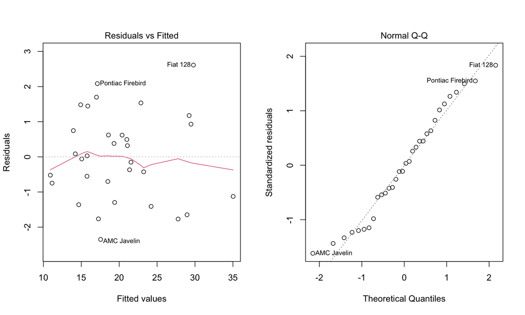

```r
par(mfrow=c(1,2))
plot(lm.both2,which=1:2)
```

Let’s also check with CV to compare these 4 models we’ve fit? Below, we use `formula()` to extract the final formulae of each model so we can refit with `x=TRUE, y=TRUE` to allow `cv.lm()` from the `lmvar` package to automate the CV process for us.

```r
library(lmvar)

cv.lm(lm(formula(lm.forward),data=mtcars,x=T,y=T),k=10)$MSE$mean
```

```
## [1] 7.458051
```

```r
cv.lm(lm(formula(lm.backward),data=mtcars,x=T,y=T),k=10)$MSE$mean
```

```
## [1] 7.443766
```

```r
cv.lm(lm(formula(lm.both),data=mtcars,x=T,y=T),k=10)$MSE$mean
```

```
## [1] 6.062719
```

```r
cv.lm(lm(formula(lm.both2),data=mtcars,x=T,y=T),k=10)$MSE$mean
```

```
## [1] 4.812456
```

$k=10$ here was chosen based on some empirical evidence that for smaller sample sizes, it gives slightly better performance. [^1]

You can learn more about these selection methods in a regression course. If you think these methods may be useful in your group project, refer to ISLR for more information or post on the discussion board.

## Shrinkage and Regularization

The variable selection methods we just discussed involved trying out different subsets of the predictors and seeing how the model performance changed as a result.

Let’s consider an alternative approach. What if instead of trying lots of different models with different numbers of predictors, we went ahead and fit a model with all $p$ available predictors, but we modify our loss function in such a way that we will set the coefficients of “unhelpful” predictors to zero? This is usually called “shrinkage”, because we shrink the coefficients toward zero. You will also often hear the term *regularization*, which is popular in machine learning, and means more or less the same thing.

Let’s briefly discuss two such methods, undoubtedly two of the most important tools in the statistical toolbox: ridge regression and the LASSO.

### Ridge regression

By now you are bored to death of seeing the linear regression least squares objective, but here it is again:
$$\sum_{i=1}^n \left( Y_i - \beta_0 - \sum_{j=1}^p \beta_j X_{i,j} \right)^2$$
Here we are assuming that we have $p$ predictors, so each $(X_i,Y_i)$ pair has a vector of predictors $X_i = (X_{i,1},X_{i,2},\dots,X_{i,p}) \in \mathbb{R}^p$ and response $Y_i \in \mathbb{R}$.

Remember, we’re trying to minimize this RSS by choosing the coefficients $\beta_j$, $j=0,1,2,\dots,p$ in a clever way.

*Ridge regression* shrinks these estimated coefficients toward zero by changing the loss slightly. Instead of minimizing the RSS alone, we add a penalty term:
$$\sum_{i=1}^n \left( Y_i - \beta_0 - \sum_{j=1}^p \beta_j X_{i,j} \right)^2
+ \lambda \sum_{j=1}^p \beta_j^2
= \operatorname{RSS} + \lambda \sum_{j=1}^p \beta_j^2$$
where $\lambda \ge 0$ is a *tuning parameter* (which we have to choose– more on that soon).

Our cost function now has two different terms:

1. Our old friend RSS, which encourages us to choose coefficients that reproduce the observed responses accurately
2. The *shrinkage penalty* $\lambda \sum_{j=1}^p \beta_j^2$, which encourages us to choose all our coefficients (other than $\beta_0$) equal to zero. That is, it *shrinks* our solution toward the origin.

The tuning parameter $\lambda$ controls how much we care about this shrinkage penalty compared to the RSS term. When $\lambda$ is big, we “pay” more for large coefficients, so we will prefer coefficients closer to zero. When $\lambda=0$, we recover plain old least squares regression.

For each value of $\lambda$ that we choose, we get a different solution to our (regularized) regression, say, $\hat{\beta}^{(\lambda)}$. In this sense, whereas least squares linear regression gives us just one solution $\hat{\beta}$, shrinkage methods give us a whole family of solutions, corresponding to different choices of $\lambda$.

For this reason, choosing the tuning parameter $\lambda$ is crucial, but we will have only a little to say about this matter, owing to time constraints. Luckily, you already know a family of methods for choosing $\lambda$– cross validation is a very common appraoch!

#### Ridge regression on the `mtcars` data set

Let’s try this out on the `mtcars` data set, trying to predict `mpg` from all the of the available predictors, this time. One thing to bear in mind: the data set is only 32 observations, so our fits are going to be a little unstable (but this is precisely why we use regularization!).

```r
names(mtcars)
```

```
##  [1] "mpg"  "cyl"  "disp" "hp"   "drat" "wt"   "qsec" "vs"   "am"   "gear"
## [11] "carb"
```

Ridge regression is available in the `MASS` library in R.

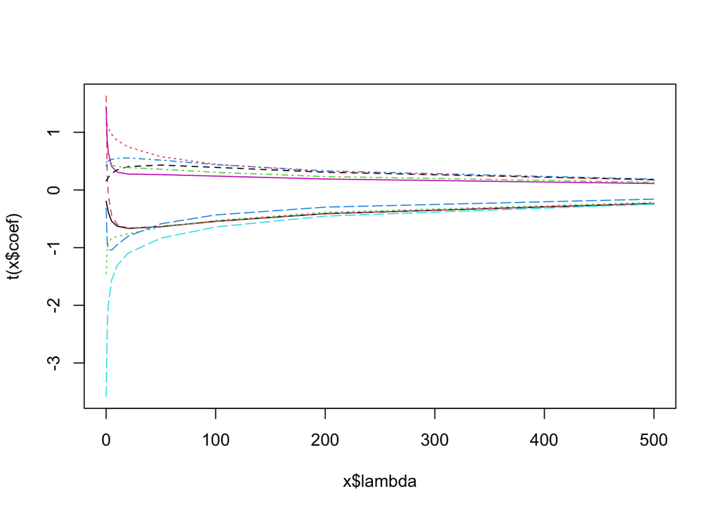

```r
library(MASS)
lambda_vals <- c(0,1,2,5,10,20,50,100,200,500) # Choose lambdas to try.

# lm.ridge needs:
# 1) a model (mpg~. says to model mpg as an intercept
#         plus a coefficient for every other variable in the data frame)
# 2) a data set (mtcars, of course)
# 3) a value for lambda. lambda=0 is the default,
#         and recovers classic linear regression.
#         But we can also pass a whole vector of lambdas, like we are about to do,
#         and lm.ridge will fit a separate model for each.
# See ?lm.ridge for details.
ridge_models <- lm.ridge(mpg~., mtcars, lambda=lambda_vals)
# Naively plotting this object shows us how the different coefficients
# change as lambda changes.
plot( ridge_models )
```

Each line in the above plot represents the coefficient of one of our predictors. The x-axis is our choice of $\lambda$ (`lambda` in the code) and the y-axis is the actual value of the coefficients.

Actually extracting those predictor labels to make a legend for this plot is annoying, and beside the point– refer to the documentation in `?lm.ridge`). The important point is that as we change $\lambda$, the coefficients change. Generally speaking, as $\lambda$ gets bigger, more coefficients are closer to zero.

Indeed, if we make $\lambda$ big enough, all of the coefficients will be zero (except the intercept, because it isn’t multiplied by $\lambda$ in the loss). That’s shrinkage!

Just as a sanity check, let’s fit plain old linear regression and verify that the coefficients with $\lambda=0$ match.

```r
lm_sanity_check <- lm(mpg~., mtcars)
lm_sanity_check$coefficients
```

```
## (Intercept)         cyl        disp          hp        drat          wt
## 12.30337416 -0.11144048  0.01333524 -0.02148212  0.78711097 -3.71530393
##        qsec          vs          am        gear        carb
##  0.82104075  0.31776281  2.52022689  0.65541302 -0.19941925
```

And compare that with

```r
head(coef( ridge_models), 1 ) # the first row is the lambda=0.0 setting.
```

```
##                     cyl       disp          hp     drat        wt      qsec
##   0 12.30337 -0.1114405 0.01333524 -0.02148212 0.787111 -3.715304 0.8210407
##            vs       am     gear       carb
##   0 0.3177628 2.520227 0.655413 -0.1994193
```

They’re the same, up to several digits of precision, anyway. Good!

#### Shrinkage and RSS

Now, for each value of $\lambda$, we get a different fitted model. How do these different models do in terms of their fit (as measured by RSS)?

Well, annoyingly, the object returned by `lm.ridge` does not include a `residuals` attribute the same way that the `lm` object does:

```r
mean( lm_sanity_check$residuals^2 )
```

```
## [1] 4.609201
```

More annoyingly still, the object returned by `lm.ridge` also does not include a `predict` method, so we can just call something like `predict( model, data)` the way we would with the output of `lm`:

```r
mean( (predict( lm_sanity_check, mtcars) - mtcars$mpg )^2 )
```

```
## [1] 4.609201
```

So, we have to roll our own predict/residuals computation. This is going to be a bit complicated, but it’s worth the detour to get some programming practice.

Our ridge regression model has coefficients: one set of coefficients for each value of lambda that we passed in.

```r
length( lambda_vals )
```

```
## [1] 10
```

Those estimated coefficients are stored in a matrix. Each column of this matrix corresponds to a coefficient (including the intercept, the first column. Each row corresponds to one $\lambda$ value.

```r
coef(ridge_models)
```

```
##                     cyl          disp           hp      drat         wt
##   0 12.30337 -0.1114405  0.0133352399 -0.021482119 0.7871110 -3.7153039
##   1 16.53766 -0.1624028  0.0023330776 -0.014934856 0.9246313 -2.4611460
##   2 18.55460 -0.2212878 -0.0007347273 -0.013481440 0.9597173 -2.0619305
##   5 20.72198 -0.3079969 -0.0036206803 -0.012460649 1.0060841 -1.6219933
##  10 21.27391 -0.3563891 -0.0048700433 -0.011966312 1.0409643 -1.3618221
##  20 20.88322 -0.3792044 -0.0054324669 -0.011248991 1.0545238 -1.1389693
##  50 19.85752 -0.3614183 -0.0052401829 -0.009609992 0.9828882 -0.8673112
## 100 19.37410 -0.3092845 -0.0044742424 -0.007814946 0.8353896 -0.6656981
## 200 19.29829 -0.2337711 -0.0033702943 -0.005732613 0.6286426 -0.4706006
## 500 19.54099 -0.1331434 -0.0019134597 -0.003201881 0.3567082 -0.2559721
##           qsec        vs        am      gear        carb
##   0 0.82104075 0.3177628 2.5202269 0.6554130 -0.19941925
##   1 0.49258752 0.3746517 2.3083758 0.6857159 -0.57579125
##   2 0.36772540 0.4389536 2.1835666 0.6545252 -0.64772938
##   5 0.23220486 0.5749017 1.9622086 0.5933014 -0.65548632
##  10 0.17615173 0.7007040 1.7537869 0.5573491 -0.59737336
##  20 0.15680180 0.8158626 1.5168704 0.5362044 -0.50497523
##  50 0.15120048 0.8706103 1.1764833 0.4942313 -0.36858373
## 100 0.13669747 0.7898063 0.9064651 0.4225302 -0.27224119
## 200 0.10798351 0.6187171 0.6407444 0.3195920 -0.18719020
## 500 0.06363418 0.3611011 0.3479026 0.1819390 -0.09983672
```

So we can pick out the coefficients associated to a particular `lambda` value by taking the corresponding row of this matrix. For example, $\lambda = 5$ is in the 4-th row of the matrix:

```r
cat(paste0("The 4-th lambda value is: ", lambda_vals[4]) )
```

```
## The 4-th lambda value is: 5
```

```r
coef( ridge_models )[4,] # Pick out the 4-th row. these are coefs when lambda=5.
```

```
##                     cyl        disp          hp        drat          wt
## 20.72198423 -0.30799694 -0.00362068 -0.01246065  1.00608409 -1.62199325
##        qsec          vs          am        gear        carb
##  0.23220486  0.57490168  1.96220860  0.59330141 -0.65548632
```

Now, to get our prediction from these coefficients, we have to multiply each predictor by its coefficient and add the intercept term. Equivalently, we can think of adding an extra predictor that is just $1$ for every observation. Something like
$$\beta_0 + \sum_{j=1}^p \beta_j X_{i,j}
= \sum_{j=0}^p \beta_j X_{i,j},$$
As an aside, for those that have taken linear algebra, you should be looking at that and thinking “that’s just an inner product!”
$$\beta^T X_i = \sum_{j=0}^p \beta_j X_{i,j}.$$

So let’s modify the `mtcars` data to make that all easy.

```r
# The mpg column of mtcars needs to get removed (it is the outcome,
# not a predictor), so we drop it-- it's the column numbered 1.
# And we're using cbind to add a column of 1s with column name const.
mtc_predictors <- cbind(const=1,mtcars[,-c(1)])
head(mtc_predictors)
```

```
##                   const cyl disp  hp drat    wt  qsec vs am gear carb
## Mazda RX4             1   6  160 110 3.90 2.620 16.46  0  1    4    4
## Mazda RX4 Wag         1   6  160 110 3.90 2.875 17.02  0  1    4    4
## Datsun 710            1   4  108  93 3.85 2.320 18.61  1  1    4    1
## Hornet 4 Drive        1   6  258 110 3.08 3.215 19.44  1  0    3    1
## Hornet Sportabout     1   8  360 175 3.15 3.440 17.02  0  0    3    2
## Valiant               1   6  225 105 2.76 3.460 20.22  1  0    3    1
```

Now, to make a prediction on, say, the `Datsun 710` observation, we need to multiply each predictor (including the `const` column) by its coefficient, and sum up the total. Again, something like
$$\sum_{j=0}^p \beta_j X_{i,j},$$
where $X_{i,0}=1$ is the extra constant term that we tacked on.

So to get the prediction for a particular observation (again, say, the `Datsun 710` row in `mtcars`), we need to make this sum (i.e., inner product) between that row of the predictors matrix and the vector of coefficients.

```r
beta5 <- coef( ridge_models )[4,] # 4th row was for lambda=5.
datsun <- mtc_predictors['Datsun 710',]
sum( beta5*datsun )
```

```
## [1] 26.62668
```

As a sanity check, let’s verify that the 1-th row, which is $\lambda=0$, agrees with our linear model’s prediction.

```r
beta0 <- coef( ridge_models )[1,] # 1st row was for lambda=0, i.e., plain old LR.
datsun <- mtc_predictors['Datsun 710',]
sum( beta0*datsun )
```

```
## [1] 26.25064
```

and compare with

```r
predict( lm_sanity_check, datsun )
```

```
## Datsun 710
##   26.25064
```

Okay, but to compute the RSS of our model we want to compute predictions for *all 32* of our observations in the `mtcars` data set. **And** we want to compute those predictions for each of our different choices of $\lambda$.

We’re going to get those predictions in a matrix. If you haven’t taken linear algebra, don’t let the word scare you. In this context, it’s enough to just think of a matrix as a big box of numbers.

Now, we currently have two boxes of numbers. One is `mtc_predictors`. Each row is an observation (so there are 32 rows), and each row has 11 entries, corresponding to the intercept term and ten additional predictors.

```r
dim( mtc_predictors )
```

```
## [1] 32 11
```

The other box of numbers is our collection of coefficients. One row for each of the models we fit (i.e., $\lambda$ values), and one column for each predictor.

```r
beta_matrix <- coef( ridge_models )
dim(beta_matrix)
```

```
## [1] 10 11
```

```r
beta_matrix
```

```
##                     cyl          disp           hp      drat         wt
##   0 12.30337 -0.1114405  0.0133352399 -0.021482119 0.7871110 -3.7153039
##   1 16.53766 -0.1624028  0.0023330776 -0.014934856 0.9246313 -2.4611460
##   2 18.55460 -0.2212878 -0.0007347273 -0.013481440 0.9597173 -2.0619305
##   5 20.72198 -0.3079969 -0.0036206803 -0.012460649 1.0060841 -1.6219933
##  10 21.27391 -0.3563891 -0.0048700433 -0.011966312 1.0409643 -1.3618221
##  20 20.88322 -0.3792044 -0.0054324669 -0.011248991 1.0545238 -1.1389693
##  50 19.85752 -0.3614183 -0.0052401829 -0.009609992 0.9828882 -0.8673112
## 100 19.37410 -0.3092845 -0.0044742424 -0.007814946 0.8353896 -0.6656981
## 200 19.29829 -0.2337711 -0.0033702943 -0.005732613 0.6286426 -0.4706006
## 500 19.54099 -0.1331434 -0.0019134597 -0.003201881 0.3567082 -0.2559721
##           qsec        vs        am      gear        carb
##   0 0.82104075 0.3177628 2.5202269 0.6554130 -0.19941925
##   1 0.49258752 0.3746517 2.3083758 0.6857159 -0.57579125
##   2 0.36772540 0.4389536 2.1835666 0.6545252 -0.64772938
##   5 0.23220486 0.5749017 1.9622086 0.5933014 -0.65548632
##  10 0.17615173 0.7007040 1.7537869 0.5573491 -0.59737336
##  20 0.15680180 0.8158626 1.5168704 0.5362044 -0.50497523
##  50 0.15120048 0.8706103 1.1764833 0.4942313 -0.36858373
## 100 0.13669747 0.7898063 0.9064651 0.4225302 -0.27224119
## 200 0.10798351 0.6187171 0.6407444 0.3195920 -0.18719020
## 500 0.06363418 0.3611011 0.3479026 0.1819390 -0.09983672
```

Once again, each column corresponds to one of 11 predictors (the intercept term and ten non-trivial predictors), and the rows correspond to the different choice of $\lambda$.

So, for each value of $\lambda$ (i.e., each row of $\beta$), and each row of `mtc_predictors` (i.e., each observation in the data set), we want to sum up the products of the coefficients with their corresponding predictors.